# Introduction à ggplot

Denis Puthier

2018-10-10

# Présentation de ggplot2

Lorsqu’on fait des statistiques descriptives on souhaite souvent partitionner la fenêtre graphique en fonction des différents niveaux pris par une variable catégorielle (*i.e* qualitative) ou ordinale. Réaliser de tels graphiques se révèle vite assez compliqué avec les librairies de base (*graphics*, *lattice*…). Dans le but de faciliter la réalisation de tels graphiques *Hadley Wickham* a développer la librairie ggplot2 qui est rapidement devenue populaire dans le monde de la bioinformatique (ici les variables catégorielles peuvent être des gènes, groupe de gènes, chromosomes, voies de signalisation, marque de chromatine…) et les variables ordinales des classes d’expression par exemple. L’une des particularité de la librairie ggplot2 est que son développement est basé sur un modèle proposé par *Leland Wilkison* dans son ouvrage “The Grammar of Graphics”. Dans ce modèle le graphique est vu comme une entité composé de couches successives (*layers*), d’échelles (*scales*), d’un système de coordonnées et de facettes. Il faut donc créer un graphique et venir ajouter les différents éléments à l’aide de l’opérateur ‘+’. Le principe est assez déconcertant pour les utilisateurs des librairies basiques de R. Cependant, avec le temps on mesure l’intérêt de cette solution car elle nécessite moins de manipulations pour réaliser des graphiques complexes.

# Réaliser un graphique basique

Nous utiliserons par la suite le jeu de données “chickwts”. L’aide sur ce jeu de données indique:

**Chicken Weights By Feed Type:** An experiment was conducted to measure and compare the effectiveness of various feed supplements on the growth rate of chickens.

## boxplot et violin plot

Les boîtes à moustaches (*boxplots*) et diagramme en violon (violin plots) peuvent être utilisés pour représenter les distributions associées à un jeu de données. On donne ci-dessous quelques exemples.

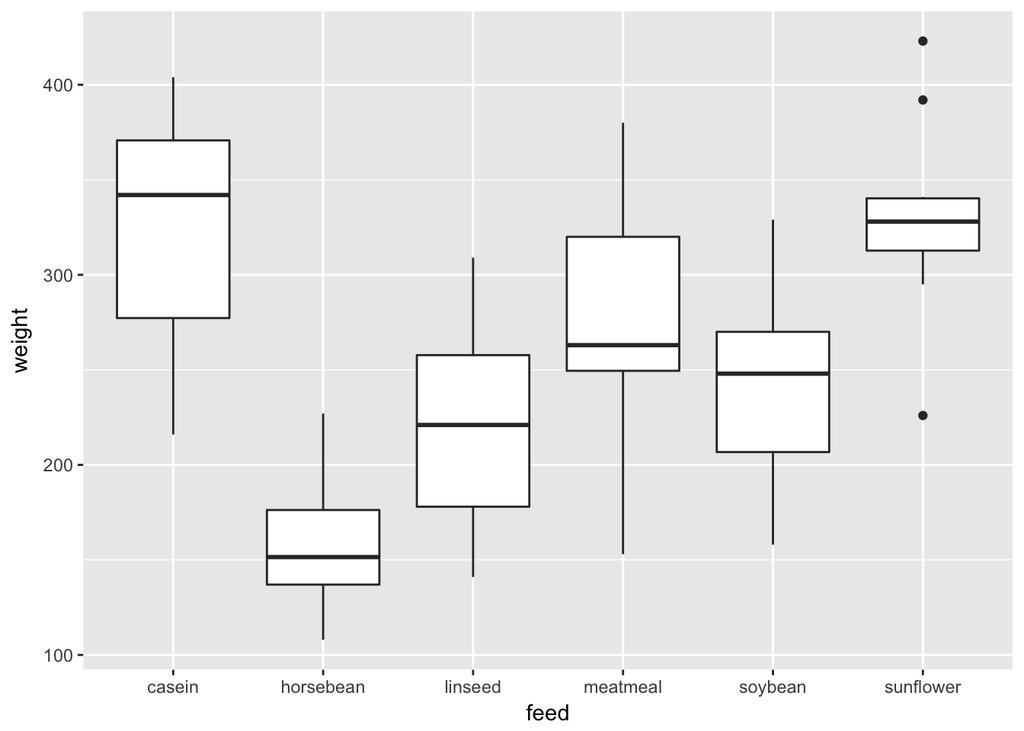

```r
## loading ggplot2 package
library(ggplot2)
## Then we can load a demonstration dataset
data(chickwts)
#View(chickwts)

## Then we declare a new graphics and associate
## a dataset. Here the aes (aesthetic) argument is set
## to feed and weight.
p <- ggplot(data=chickwts, aes( x=feed, y=weight))

## We have to indicate the type of requested graphics
p.bp <- p + geom_boxplot()
print(p.bp)
```

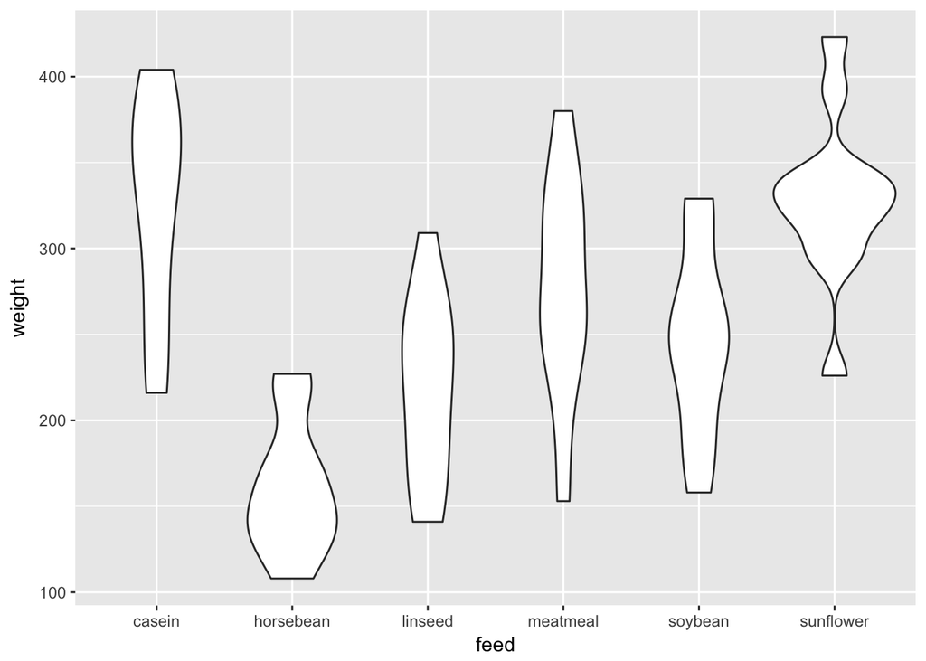

```r
## We can also easily produce a violin plot using the following instructions

p.vp <- p + geom_violin()
print(p.vp)
```

## Nuages de points

Il y a environ 40 types de graphiques disponibles. Quelques exemples présentent ci-dessous les instructions pour réaliser des nuages de points.

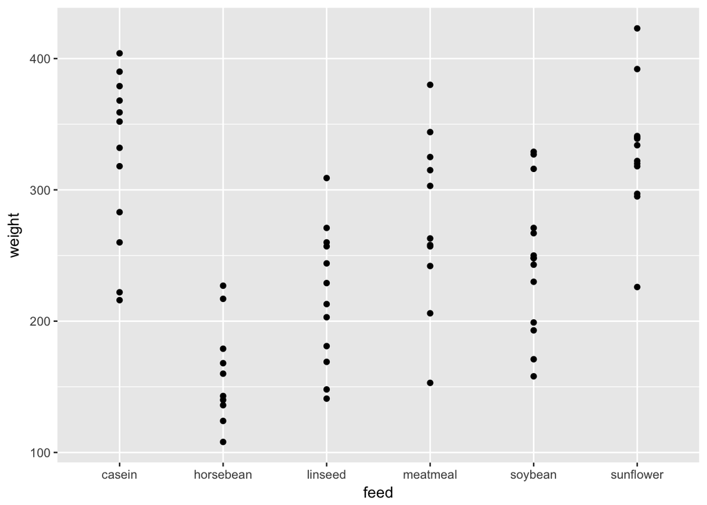

```r
## We can for instance show the values associated to each feed
p.pt <- p + geom_point()
print(p.pt)
```

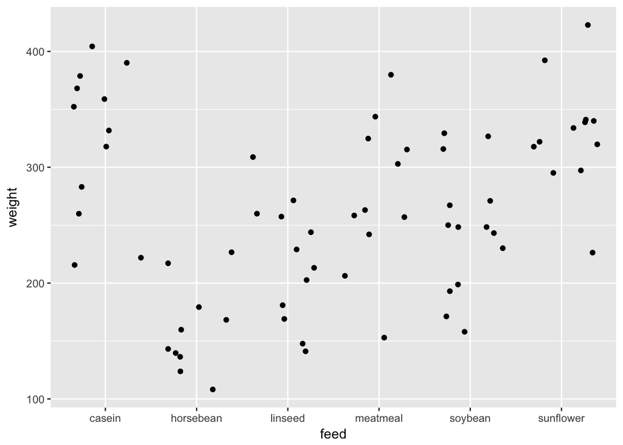

```r
## However as they are some ties it may be advised to
## use the jitter option that will add some randomness to the value of the x axis (that here are categorical but can be viewed as 1, 2, 3...)
p.jt <- p + geom_jitter()
print(p.jt)
```

## Histogrammes et densités

Dans le cas de l’histogramme, l’axe des x correspond à des intervals (*bins*) et l’axe des y au nombre de fois on les valeurs de comptage sont observés dans ces intervals. Il n’y aura donc qu’une seule variable à fournir pour la fonction *aes*.

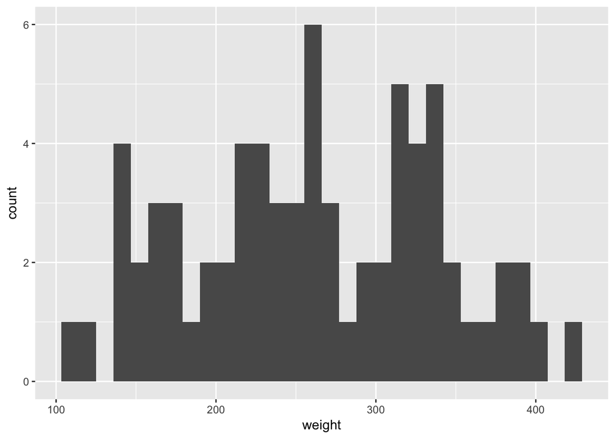

```r
## Here the code for an histogram
ggplot(data=chickwts, aes(x=weight)) + geom_histogram()
```

On peut aussi réaliser un profil de densité de probabilité en utilisant la fonction geom_density()

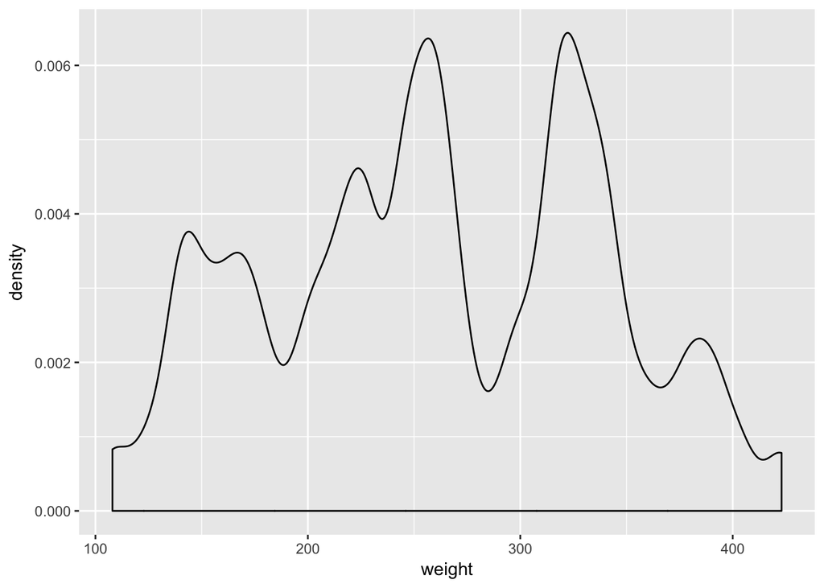

```r
ggplot(data=chickwts, aes(x=weight)) + geom_density(adjust = 1/4)
```

# Superposer des éléments graphiques

## Exemple autour du boxplot

Le modèle sous-jacent à ggplot permet de superposer relativement facilement des couches graphiques.

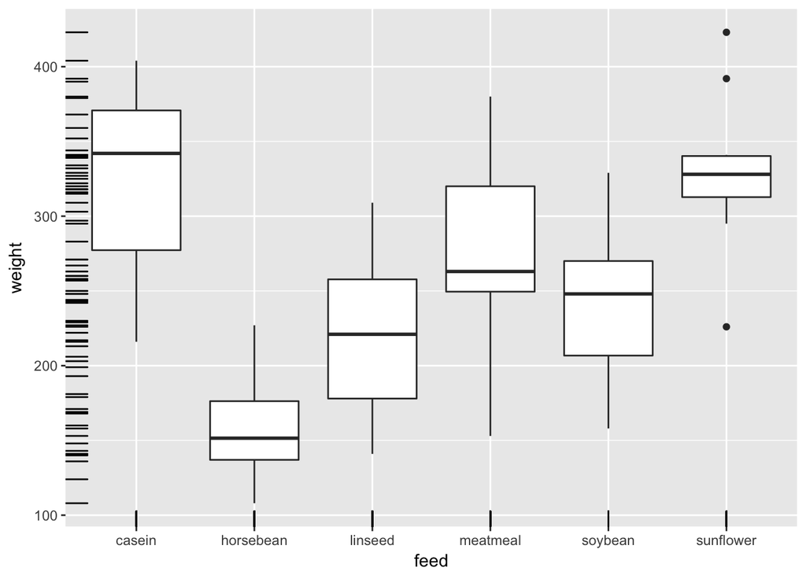

```r
## One can add a rug to the boxplot graphics
p.bp + geom_rug()
```

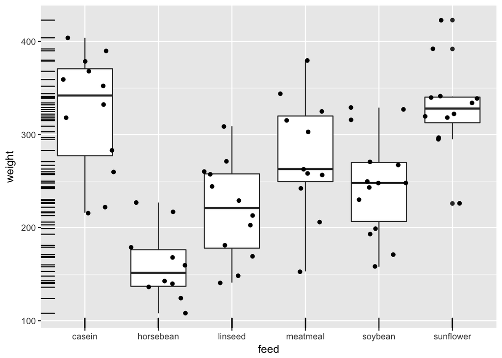

```r
## One can display the scattered values on the boxplot

p.bp + geom_jitter() + geom_rug()
```

# Facettes

L’utilisation des facettes permet d’explorer les données en fonction d’un facteur ou d’un groupe de facteurs donnés. Pour l’exemple suivant nous allons créer une matrice contenant les résultats d’un test ELISA fictif dans lequel on mesure à 2 temps différents (jours) les expériences réalisés par quatres opérateurs différents.

```r
url <- "https://tinyurl.com/ycdhmof8"
elisa <- read.table(url, sep="\t", header=TRUE, row.names=1)
head(elisa)
```

```
##   day rows columns value  user
## 1 Mon cont       A  20.0 Alain
## 2 Mon    a       A  23.0 Alain
## 3 Mon    b       A  20.3 Alain
## 4 Mon    c       A  20.8 Alain
## 5 Mon    d       A  19.4 Alain
## 6 Mon    e       A  19.0 Alain
```

```r
table(elisa$user, elisa$day)
```

```
##
##            Fri Mon
##   Alain     96  96
##   Mathilde  96  96
##   Sophie    96  96
##   Yvan      96  96
```

## Histogrammes en facettes

Il devient très facile avec la syntaxe de ggplot2 de produire des histogrammes correspondant aux expériences réalisé à un jour donné par un expérimentateur donné.

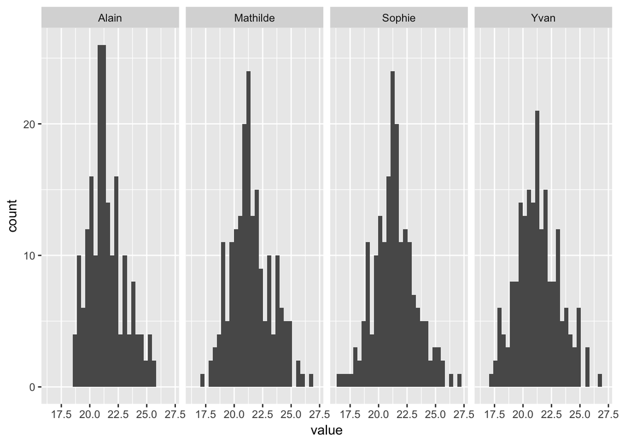

```r
p <- ggplot(data = elisa, mapping = aes(x=value))
p + geom_histogram() + facet_grid(facets = ~ user )
```

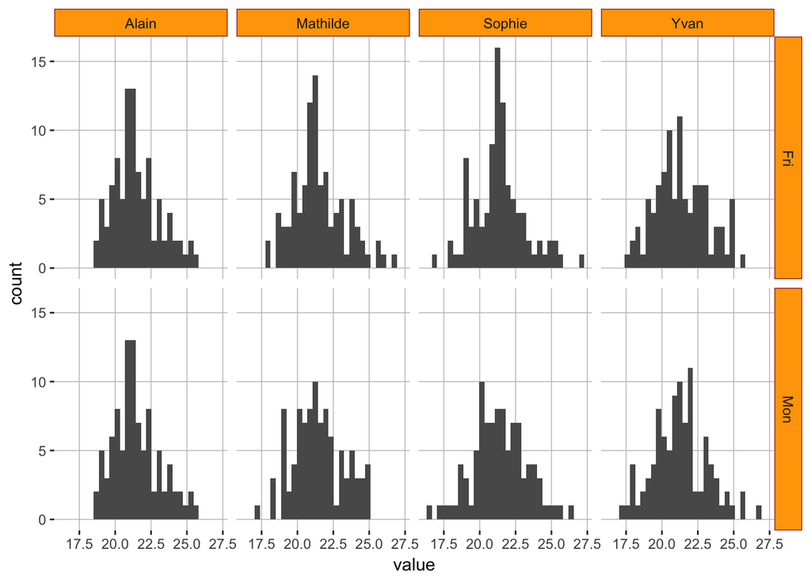

```r
p + geom_histogram() +
  facet_grid(facets = day ~ user) +
  theme(panel.background = element_rect(fill="white"),
        panel.grid.major = element_line(size = 0.25, linetype = 'solid', colour = "gray"),
        strip.background = element_rect(colour = "brown", fill="orange"),
        )
```

Dans un but exploratoire, on peut, de même, analyser les résultats obtenues dans chaques ligne de l’ELISA en fonction des colonnes Il suffit pour cela d’indiquer le formule suivante rows ~ columns. Dans l’exemple suivant on fait appelle à la fonction theme() pour personnaliser un peu le graphique. Notez que chaque argument de la fonction theme() doit recevoir un objet renvoyé par les fonction element_rect(), element_text(), ou element_line() qui correspondent respectivement à des éléments rectangulaires, du texte ou des lignes.

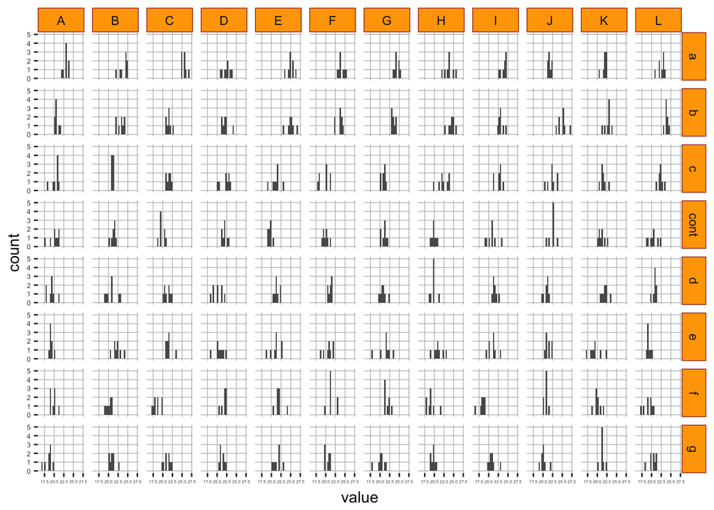

```r
## Diagram facetted with rows and columns as variable.
p + geom_histogram() +
  facet_grid(facets = rows ~ columns) +
  theme(axis.text.x = element_text(size = 3),
        axis.text.y = element_text(size = 5),
        panel.background = element_rect(fill="white"),
        panel.grid.major = element_line(size = 0.25, linetype = 'solid', colour = "gray"),
        strip.background = element_rect(colour = "brown", fill="orange"))
```

## Plans des plaques en facettes

A partir des données textuelles chargées dans R, on peut être intéressé à reproduire une image code-couleur (heatmap) des plaques ELISA produites par les différents utilisateurs. Pour ce faire il suffit d’utiliser la fonction *geom_raster()* et d’utiliser la formule adéquate.

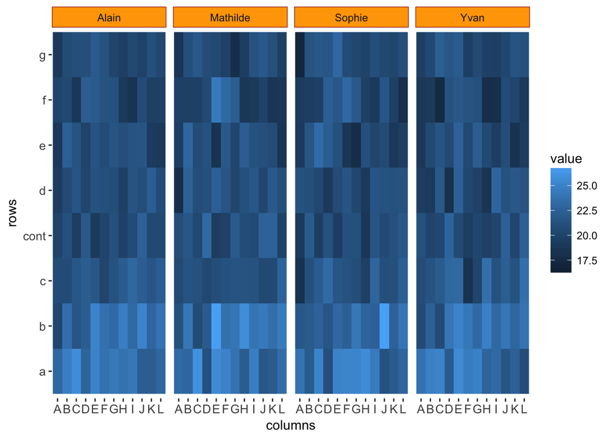

```r
p <- ggplot(data = elisa, mapping = aes(x=columns, y=rows, fill=value))
p + geom_raster() +
  facet_grid(facets = ~ user) +
  theme(axis.text.x = element_text(size = 10),
        axis.text.y = element_text(size = 10),
        panel.background = element_rect(fill="white"),
        panel.grid.major = element_line(colour = "white"),
        strip.background = element_rect(colour = "brown", fill="orange"))
```

Cependant, dans le diagramme précédent, les résultats des plaques ELISA sont mélangés… Il faut donc ajouter un facteur dans la formule, le jour.

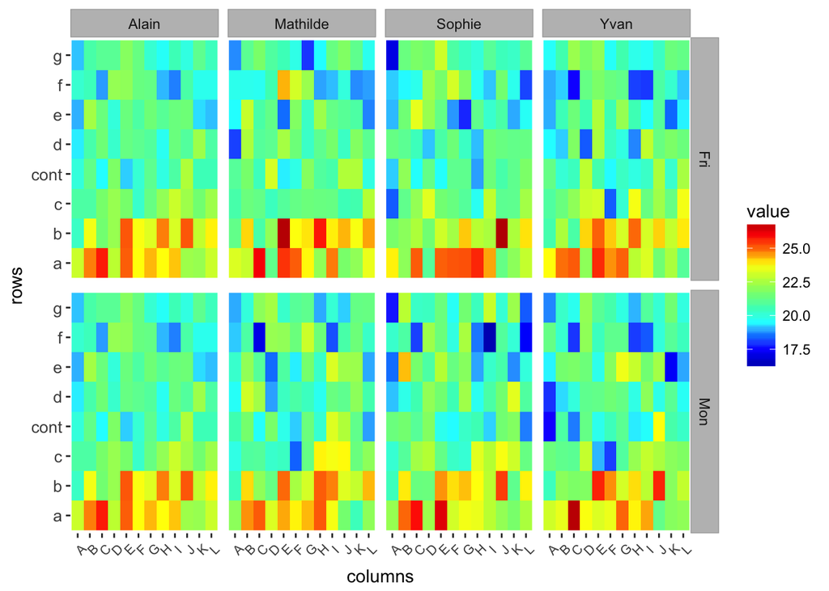

```r
p <- ggplot(data = elisa, mapping = aes(x=columns, y=rows, fill=value))
p + geom_raster() +
  facet_grid(facets = day ~ user) +
  theme(axis.text.x = element_text(size = 8, angle = 45, margin = margin(5)),
        axis.text.y = element_text(size = 10),
        panel.background = element_rect(fill="white"),
        panel.grid.major = element_line(colour = "white"),

        strip.background = element_rect(colour = "darkgray", fill="gray")) +
  scale_fill_gradientn(colours = c("#0000BF", "#0000FF",
                                   "#0080FF", "#00FFFF",
                                   "#40FFBF", "#80FF80",
                                   "#BFFF40", "#FFFF00",
                                   "#FF8000", "#FF0000",
                                   "#BF0000"))
```

# Exercices

## The dataset

Here, our dataset contains several informations related to transcripts in the human genome. They were computed using *pygtftk* (v0.9.8) from a GTF file downloaded from ensembl (genome version GRCh38, release 92). First we will load the dataset, set the row names to the transcript ids and inspect the column names.

```r
if(!require(ggplot2)){install.packages("ggplot2")}
if(!require(dplyr)){install.packages("dplyr")}
if(!require(data.table)){install.packages("data.table")}
if(!require(knitr)){install.packages("knitr")}
tx_info <- as.data.frame(fread("https://tinyurl.com/hg38-tx-info-txt", sep="\t", header = T))
rownames(tx_info)  <- tx_info[,11]
kable(colnames(tx_info))
```

| x |
| --- |
| seqid |
| source |
| feature |
| start |
| end |
| score |
| strand |
| phase |
| gene_id |
| gene_version |
| transcript_id |
| transcript_version |
| gene_name |
| gene_source |
| gene_biotype |
| transcript_name |
| transcript_source |
| transcript_biotype |
| tag |
| transcript_support_level |
| convergent |
| dist_to_convergent |
| nb_exons |
| tx_genomic_size |
| mature_rna_size |
| intron_size |
| exon_sizes |
| prom_overlap_tss_from_other_gene |
| dist_prom_overlap_tss_from_other_gene |
| divergent |
| dist_to_divergent |
| ccds_id |

First, we will only select transcript belonging to a class of *gene_biotype* which contains more than 500 transcripts.

```r
tx_info <- tx_info %>%
            group_by(gene_biotype) %>%
            filter(n() > 500)
```

Then we will use an ordered factor for chromosomes:

```r
tx_info$seqid <- factor(tx_info$seqid, ordered = T, levels = c(paste("chr", 1:22, sep=""), "chrX", "chrY"))
```

- Create a faceted histogram showing the distribution of transcript genomic size. Use *geom_histogram*.
- Compute a density showing the distribution of transcript genomic size depending on gene_biotype (use facets).
- What about ‘processed_pseudogene’ ? How do you explain this result ?
- Draw a stacked barplot showing the number of transcripts from each gene_biotype class on each chromosome.

<< Hide | Show >>

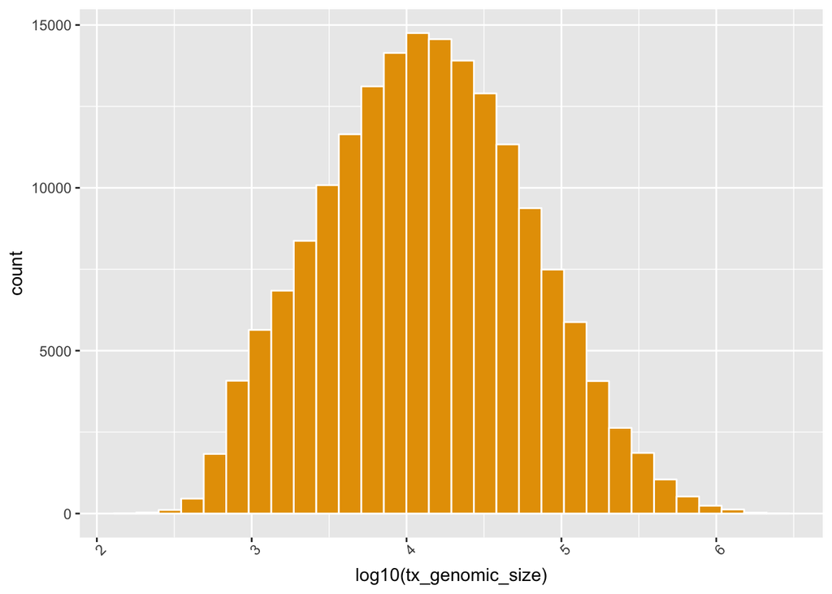

```r
## Create a faceted histogram showing the distribution of
## transcript genomic size
ggplot(tx_info, aes(x=log10(tx_genomic_size))) +
  geom_histogram(fill="#E69F00", color="white") +
  theme(axis.text.x = element_text(angle = 45))
```

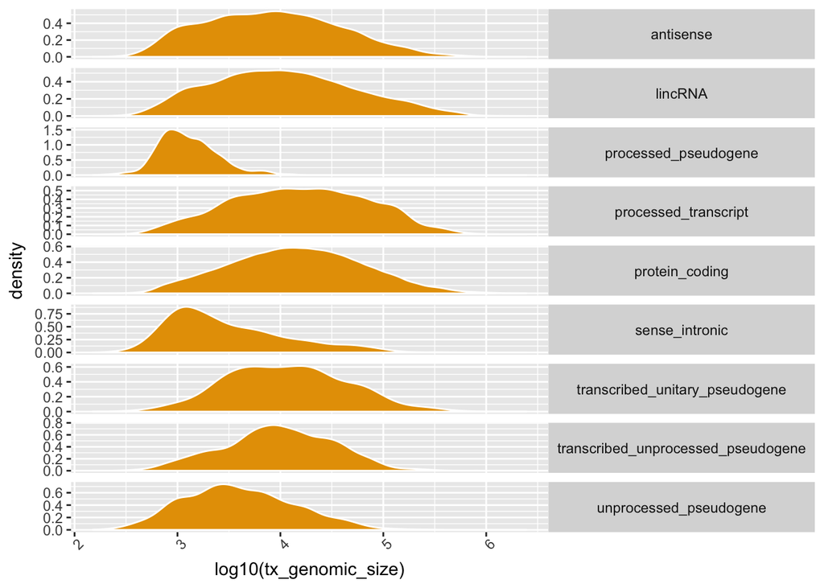

```r
## Create a faceted histogram showing the distribution of
## transcript genomic size depending on gene_biotype
ggplot(tx_info, aes(x=log10(tx_genomic_size))) +
  geom_density(fill="#E69F00", color="white") +
  theme(axis.text.x = element_text(angle = 45)) +
  facet_grid(gene_biotype~., scales  = "free_y") +
  theme(strip.text.y = element_text(angle = 0))
```

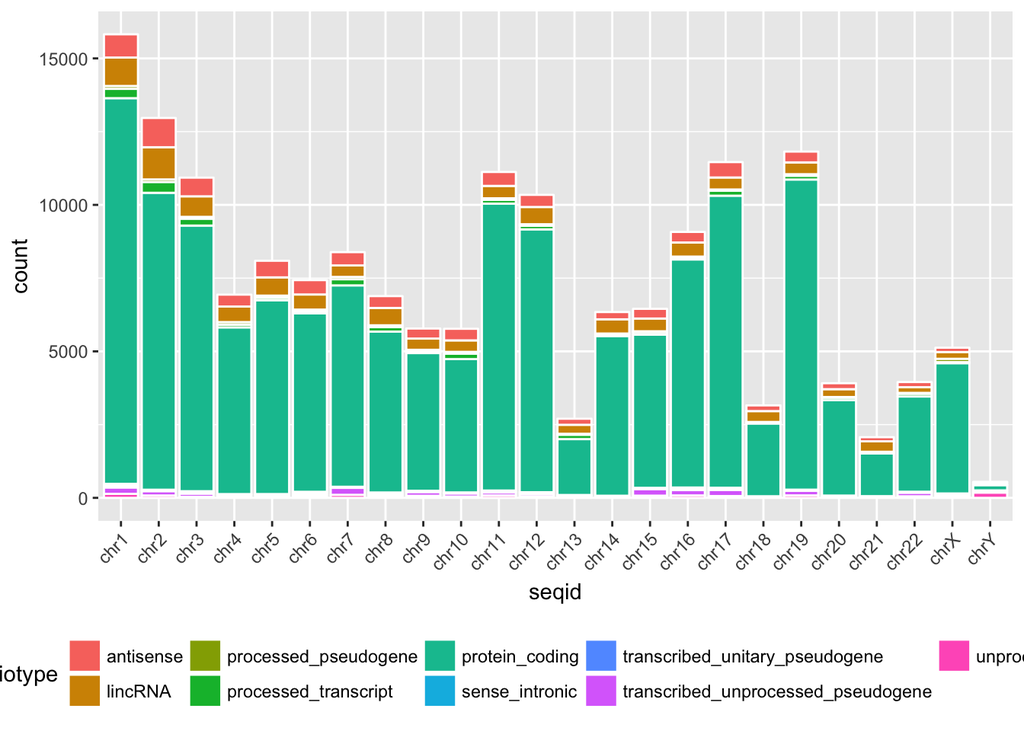

```r
## Draw a stacked barplot showing the number of transcripts from each
## gene_biotype class on each chromosome.
ggplot(tx_info, aes(x=seqid, fill=gene_biotype)) +
  geom_bar(aes(fill=gene_biotype),  color="white") +
  theme(axis.text.x = element_text(angle = 45, hjust=1)) +
  theme(strip.text.x = element_text(size = 7,
                                    colour = 'black',
                                    angle = 90),
        legend.position = "bottom")
```